# Определение стоимости автомобилей

# Table of Contents

## Описание проекта

Сервис по продаже автомобилей с пробегом «Не бит, не крашен» разрабатывает приложение для привлечения новых клиентов. В нём можно быстро узнать рыночную стоимость своего автомобиля. В вашем распоряжении исторические данные: технические характеристики, комплектации и цены автомобилей. Вам нужно построить модель для определения стоимости.

Заказчику важны:

- качество предсказания;
- скорость предсказания;
- время обучения.

## Описание данных

Признаки:

- `DateCrawled` — дата скачивания анкеты из базы
- `VehicleType` — тип автомобильного кузова
- `RegistrationYear` — год регистрации автомобиля
- `Gearbox` — тип коробки передач
- `Power` — мощность (л. с.)
- `Model` — модель автомобиля
- `Kilometer` — пробег (км)
- `RegistrationMonth` — месяц регистрации автомобиля
- `FuelType` — тип топлива
- `Brand` — марка автомобиля
- `Repaired` — была машина в ремонте или нет
- `DateCreated` — дата создания анкеты
- `NumberOfPictures` — количество фотографий автомобиля
- `PostalCode` — почтовый индекс владельца анкеты (пользователя)
- `LastSeen` — дата последней активности пользователя

Целевой признак:

- `Price` — цена (евро)

**Импортирование библиотек**

```python
!pip -q install phik
!pip -q install -U scikit-learn
!pip -q install lightgbm
!pip -q install catboost
!pip -q install shap
```

```python
import warnings
warnings.filterwarnings('ignore')
```

```python
import pandas as pd
import numpy as np
import matplotlib.pyplot as plt
import seaborn as sns
import phik
import time
import shap

import lightgbm as lgb
import catboost as cb
from sklearn.model_selection import train_test_split, cross_val_score, GridSearchCV
from sklearn.pipeline import Pipeline
from sklearn.compose import ColumnTransformer
from sklearn.preprocessing import (
    StandardScaler, OneHotEncoder, OrdinalEncoder
)
from sklearn.impute import SimpleImputer
from sklearn.linear_model import LinearRegression

from sklearn.model_selection import cross_val_score
from sklearn.model_selection import KFold
from sklearn.metrics import mean_squared_error
from sklearn.tree import DecisionTreeRegressor
```

```python
# Настройки вывода графиков
plt.rcParams["axes.titlesize"] = 16  # Размер шрифта
plt.rcParams["axes.titleweight"] = "bold"  # Толщина шрифта

# Константы
RANDOM_STATE = 42
TEST_SIZE = 0.25
TERM_SIZE = 180
```

## Загрузка данных

```python
try:
    autos = pd.read_csv("C:\\Data-science\\ds_csv\\autos.csv")
except:
    try:
        autos = pd.read_csv('/datasets/autos.csv')
    except:
        raise FileNotFoundError
```

### Изучение загруженного датасета

```python
autos.info()
autos.head(10)
```

```
<class 'pandas.core.frame.DataFrame'>
RangeIndex: 354369 entries, 0 to 354368
Data columns (total 16 columns):
 #   Column             Non-Null Count   Dtype
---  ------             --------------   -----
 0   DateCrawled        354369 non-null  object
 1   Price              354369 non-null  int64
 2   VehicleType        316879 non-null  object
 3   RegistrationYear   354369 non-null  int64
 4   Gearbox            334536 non-null  object
 5   Power              354369 non-null  int64
 6   Model              334664 non-null  object
 7   Kilometer          354369 non-null  int64
 8   RegistrationMonth  354369 non-null  int64
 9   FuelType           321474 non-null  object
 10  Brand              354369 non-null  object
 11  Repaired           283215 non-null  object
 12  DateCreated        354369 non-null  object
 13  NumberOfPictures   354369 non-null  int64
 14  PostalCode         354369 non-null  int64
 15  LastSeen           354369 non-null  object
dtypes: int64(7), object(9)
memory usage: 43.3+ MB
```

|  | DateCrawled | Price | VehicleType | RegistrationYear | Gearbox | Power | Model | Kilometer | RegistrationMonth | FuelType | Brand | Repaired | DateCreated | NumberOfPictures | PostalCode | LastSeen |
| --- | --- | --- | --- | --- | --- | --- | --- | --- | --- | --- | --- | --- | --- | --- | --- | --- |
| 0 | 2016-03-24 11:52:17 | 480 | NaN | 1993 | manual | 0 | golf | 150000 | 0 | petrol | volkswagen | NaN | 2016-03-24 00:00:00 | 0 | 70435 | 2016-04-07 03:16:57 |
| 1 | 2016-03-24 10:58:45 | 18300 | coupe | 2011 | manual | 190 | NaN | 125000 | 5 | gasoline | audi | yes | 2016-03-24 00:00:00 | 0 | 66954 | 2016-04-07 01:46:50 |
| 2 | 2016-03-14 12:52:21 | 9800 | suv | 2004 | auto | 163 | grand | 125000 | 8 | gasoline | jeep | NaN | 2016-03-14 00:00:00 | 0 | 90480 | 2016-04-05 12:47:46 |
| 3 | 2016-03-17 16:54:04 | 1500 | small | 2001 | manual | 75 | golf | 150000 | 6 | petrol | volkswagen | no | 2016-03-17 00:00:00 | 0 | 91074 | 2016-03-17 17:40:17 |
| 4 | 2016-03-31 17:25:20 | 3600 | small | 2008 | manual | 69 | fabia | 90000 | 7 | gasoline | skoda | no | 2016-03-31 00:00:00 | 0 | 60437 | 2016-04-06 10:17:21 |
| 5 | 2016-04-04 17:36:23 | 650 | sedan | 1995 | manual | 102 | 3er | 150000 | 10 | petrol | bmw | yes | 2016-04-04 00:00:00 | 0 | 33775 | 2016-04-06 19:17:07 |
| 6 | 2016-04-01 20:48:51 | 2200 | convertible | 2004 | manual | 109 | 2_reihe | 150000 | 8 | petrol | peugeot | no | 2016-04-01 00:00:00 | 0 | 67112 | 2016-04-05 18:18:39 |
| 7 | 2016-03-21 18:54:38 | 0 | sedan | 1980 | manual | 50 | other | 40000 | 7 | petrol | volkswagen | no | 2016-03-21 00:00:00 | 0 | 19348 | 2016-03-25 16:47:58 |
| 8 | 2016-04-04 23:42:13 | 14500 | bus | 2014 | manual | 125 | c_max | 30000 | 8 | petrol | ford | NaN | 2016-04-04 00:00:00 | 0 | 94505 | 2016-04-04 23:42:13 |
| 9 | 2016-03-17 10:53:50 | 999 | small | 1998 | manual | 101 | golf | 150000 | 0 | NaN | volkswagen | NaN | 2016-03-17 00:00:00 | 0 | 27472 | 2016-03-31 17:17:06 |

В датасете присутствуют пропуски, определим их процентное соотношение

```python
print("\033[1mПроцент пропусков от всего датасета:\033[0m")
print()
formatted_output = autos.isna().mean().sort_values(ascending=False).apply(lambda x: "{:.1%}".format(x))
print(formatted_output)
```

```
Процент пропусков от всего датасета:

Repaired             20.1%
VehicleType          10.6%
FuelType              9.3%
Gearbox               5.6%
Model                 5.6%
DateCrawled           0.0%
Price                 0.0%
RegistrationYear      0.0%
Power                 0.0%
Kilometer             0.0%
RegistrationMonth     0.0%
Brand                 0.0%
DateCreated           0.0%
NumberOfPictures      0.0%
PostalCode            0.0%
LastSeen              0.0%
dtype: object
```

## Предобработка данных

### Исправление названия колонок

```python
autos = autos.rename(columns={
    'DateCrawled': 'date_craweled',
    'Price': 'price',
    'VehicleType': 'vehicle_type',
    'RegistrationYear': 'registration_year',
    'Gearbox': 'gearbox',
    'Power': 'power',
    'Model': 'model',
    'Kilometer': 'kilometer',
    'RegistrationMonth': 'registration_month',
    'FuelType': 'fuel_type',
    'Brand': 'brand',
    'Repaired': 'repaired',
    'DateCreated': 'date_created',
    'NumberOfPictures': 'number_of_pictures',
    'PostalCode': 'postal_code',
    'LastSeen': 'last_seen'
})

# Проверка
autos.columns
```

```
Index(['date_craweled', 'price', 'vehicle_type', 'registration_year',
       'gearbox', 'power', 'model', 'kilometer', 'registration_month',
       'fuel_type', 'brand', 'repaired', 'date_created', 'number_of_pictures',
       'postal_code', 'last_seen'],
      dtype='object')
```

### Удаление столбцов не имеющих смысловой нагрузки для поставленной задачи

Столбец `postal_code` почтовый индекс владельца анкеты, не влияет на состояние автомобиля, также `date_craweled` - дата скачивания анкеты из базы, нам не важно когда объявление было скачено для его анализа. Столбцы `date_created` и `last_seen` имеют схожую информацию о времени создания или последнего изменения анкеты, нам важнее знать окончательную цену, поэтому оставим только столбец `last_seen`

```python
autos = autos.drop(['postal_code', 'date_craweled', 'date_created'], axis=1)
```

Проверим столбец `number_of_pictures` униккальность значений, т.к. в первых 10-ти строчках встречается только значение 0

```python
autos['number_of_pictures'].nunique()
```

```
1
```

Cтолбец `number_of_pictures` имеет только одно значение 0. Поэтому этот столбец неинформативен для анализа, его следует удалить.

```python
autos = autos.drop(['number_of_pictures'], axis=1)
```

### Приведем столбцы со временем к правильному формату

```python
# Преобразуем в datetime
autos['last_seen'] = pd.to_datetime(autos['last_seen'], errors='coerce')

# отбросим время через strftime
autos['last_seen'] = autos['last_seen'].dt.strftime('%Y-%m-%d')

# И снова в datetime64[ns]
autos['last_seen'] = pd.to_datetime(autos['last_seen'])
# Проверка
display(autos['last_seen'].dtype)
autos.head()
```

```
dtype('<M8[ns]')
```

|  | price | vehicle_type | registration_year | gearbox | power | model | kilometer | registration_month | fuel_type | brand | repaired | last_seen |
| --- | --- | --- | --- | --- | --- | --- | --- | --- | --- | --- | --- | --- |
| 0 | 480 | NaN | 1993 | manual | 0 | golf | 150000 | 0 | petrol | volkswagen | NaN | 2016-04-07 |
| 1 | 18300 | coupe | 2011 | manual | 190 | NaN | 125000 | 5 | gasoline | audi | yes | 2016-04-07 |
| 2 | 9800 | suv | 2004 | auto | 163 | grand | 125000 | 8 | gasoline | jeep | NaN | 2016-04-05 |
| 3 | 1500 | small | 2001 | manual | 75 | golf | 150000 | 6 | petrol | volkswagen | no | 2016-03-17 |
| 4 | 3600 | small | 2008 | manual | 69 | fabia | 90000 | 7 | gasoline | skoda | no | 2016-04-06 |

### Работа с пропусками

```python
cat_features = [
    'vehicle_type',
    'gearbox',
    'model',
    'registration_month',
    'fuel_type',
    'brand',
    'repaired'
]

# Заполнение пропусков у категориальных признаков
autos[cat_features] = autos[cat_features].fillna('no_info')
```

```python
# Проверка
print("\033[1mПроцент пропусков от всего датасета:\033[0m")
print()
formatted_output = autos.isna().mean().sort_values(ascending=False).apply(lambda x: "{:.1%}".format(x))
print(formatted_output)
```

```
Процент пропусков от всего датасета:

price                 0.0%
vehicle_type          0.0%
registration_year     0.0%
gearbox               0.0%
power                 0.0%
model                 0.0%
kilometer             0.0%
registration_month    0.0%
fuel_type             0.0%
brand                 0.0%
repaired              0.0%
last_seen             0.0%
dtype: object
```

### Работа с дубликатами

```python
print(f'Явных дубликатов: {autos.duplicated().sum()}' if autos.duplicated().sum() > 0 else 'Явных дубликатов НЕТ')
```

```
Явных дубликатов: 12040
```

```python
display(f'Количество строк до удаления дубликатов {autos.shape[0]}')

autos = autos.drop_duplicates()

display(f'Количество строк после удаления дубликатов {autos.shape[0]}')
```

```
'Количество строк до удаления дубликатов 354369'
```

```
'Количество строк после удаления дубликатов 342329'
```

## Статистический анализ

### Объявление функций для построения графиков

```python
def show_num_variable(df, column, target=None):
    '''
    Функция отображения гистограммы распределения
    и диаграммы размаха для определенного столбца датафрейма
    с учетом принадлежности данного столбца к разным значениям
    переменной target.

    Параметры:
    - df: pandas.DataFrame, входной датафрейм
    - column: str, столбец для анализа
    - target: str или None, столбец для группировки (по умолчанию None)
    '''
    sns.set()
    f, axes = plt.subplots(1, 2, figsize=(16, 6))

    # Гистограмма
    axes[0].set_title(f'Гистограмма для {column}', fontsize=16)
    axes[0].set_ylabel('Количество', fontsize=14)
    if target:
        sns.histplot(data=df, bins=20, kde=True, ax=axes[0], hue=target, x=column)
    else:
        sns.histplot(data=df, bins=20, kde=True, ax=axes[0], x=column)

    # Диаграмма размаха
    axes[1].set_title(f'Диаграмма размаха для {column}', fontsize=16)
    if target:
        sns.boxplot(data=df, ax=axes[1], x=target, y=column)
    else:
        sns.boxplot(data=df, ax=axes[1], y=column, orient='v')
    axes[1].set_ylabel(column, fontsize=14)

    plt.tight_layout()
    plt.show()
```

```python
def show_cat_variable_by_target(df, column, title, target=None, rot=60):
    '''
    Функция отображения соотношения категориальных признаков
    в столбце датафрейма, разделенных по значениям целевого признака.
    Если target не передан, отображается только countplot для column.
    Добавляет проценты на график.

    :param df: DataFrame, датафрейм с данными
    :param column: str, название столбца, по которому строится график
    :param title: str, заголовок графика
    :param target: str, название столбца с целевым признаком (по умолчанию None)
    :param rot: int, угол поворота меток на оси X
    '''

    # Если target не указан, рисуем только countplot для одного признака
    if target is None:
        plt.figure(figsize=(16, 6))
        ax = sns.countplot(data=df, x=column)
        ax.set_title(f"{title}", fontsize=14)
        ax.set_xlabel(column, fontsize=12)
        ax.set_ylabel('Количество', fontsize=12)
        ax.tick_params(axis='x', rotation=rot)

        # Добавляем проценты на график
        total_count = len(df)
        for p in ax.patches:
            count = p.get_height()
            if count > 0:  # Добавляем проценты только если высота столбца > 0
                percentage = f'{100 * count / total_count:.1f}%'
                ax.annotate(percentage,
                            (p.get_x() + p.get_width() / 2., count),
                            ha='center', va='center',
                            xytext=(0, 10),
                            textcoords='offset points',
                            fontsize=12, color='black')

        plt.tight_layout()
        plt.show()
        return

    # Проверяем, что столбец target существует в DataFrame
    if target not in df.columns:
        raise ValueError(f"Столбец '{target}' не найден в DataFrame.")

    # Если target указан, строим графики для каждого уникального значения target
    unique_targets = df[target].unique()
    num_targets = len(unique_targets)

    # Определяем размер холста в зависимости от количества таргетов
    fig, axes = plt.subplots(nrows=num_targets, ncols=1, figsize=(12, 5 * num_targets), sharex=True)

    # Если уникальных значений больше одного, axes будет массивом
    # Если только одно значение, делаем axes списком для унификации
    if num_targets == 1:
        axes = [axes]

    # Создаем график для каждого уникального значения целевого признака
    for i, target_value in enumerate(unique_targets):
        # Создаем подмножество данных для текущего значения целевого признака
        subset = df[df[target] == target_value]

        # Получаем уникальные значения категориального признака для сортировки
        categories = subset[column].value_counts().index.tolist()

        # Создаем countplot для текущего значения целевого признака
        ax = sns.countplot(data=subset, x=column, ax=axes[i], order=categories)

        # Заголовок и настройка осей
        axes[i].set_title(f"{title}: {target} - {target_value}", fontsize=14)
        axes[i].set_xlabel(column if i == num_targets - 1 else "", fontsize=12)  # Подпись только для нижнего графика
        axes[i].set_ylabel('Количество', fontsize=12)
        axes[i].tick_params(axis='x', rotation=rot)

        # Вычисляем общее количество для текущей группы
        total_count = len(subset)

        # Добавляем проценты на столбцы
        for p in ax.patches:
            count = p.get_height()
            if count > 0:  # Добавляем проценты только если высота столбца > 0
                percentage = f'{100 * count / total_count:.1f}%'
                # Вычисляем координаты для аннотации (верхняя часть столбца)
                ax.annotate(percentage,
                            (p.get_x() + p.get_width() / 2., count),
                            ha='center', va='center',
                            xytext=(0, 10),
                            textcoords='offset points',
                            fontsize=12, color='black')

    # Улучшаем отображение
    plt.tight_layout(h_pad=2.0)  # Добавляем вертикальный отступ между графиками
    plt.show()
```

### Анализ количественных и качественных признаков

```python
# Формирование списка столбцов с количественными признаками
num_variables_col = autos.select_dtypes(include=['number']).columns.to_list()
num_variables_col.remove('registration_month')
num_variables_col
```

```
['price', 'registration_year', 'power', 'kilometer']
```

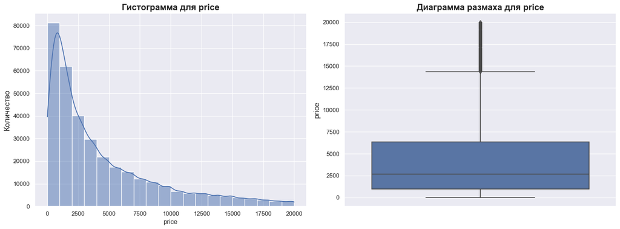

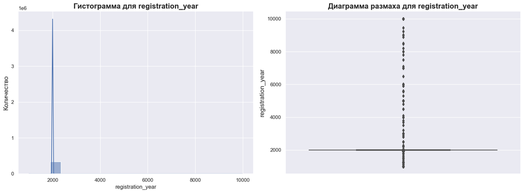

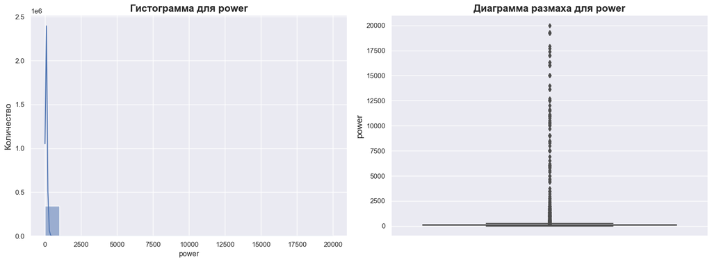

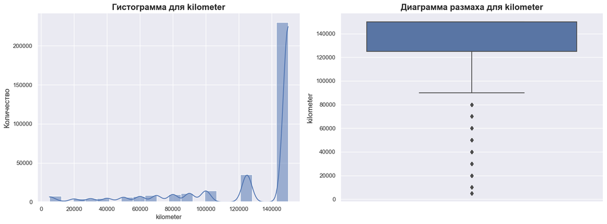

```python
# Вывод графиков для количественных признаков датафрейма autos
for col in num_variables_col:
    show_num_variable(autos, col)
    print('=' * TERM_SIZE)
```

```python
autos.drop(columns=['registration_month', 'last_seen']).describe().round(3)
```

|  | price | registration_year | power | kilometer |
| --- | --- | --- | --- | --- |
| count | 342329.000 | 342329.000 | 342329.000 | 342329.000 |
| mean | 4403.123 | 2004.238 | 110.029 | 128215.576 |
| std | 4514.741 | 91.406 | 191.942 | 37926.407 |
| min | 0.000 | 1000.000 | 0.000 | 5000.000 |
| 25% | 1000.000 | 1999.000 | 68.000 | 125000.000 |
| 50% | 2700.000 | 2003.000 | 105.000 | 150000.000 |
| 75% | 6350.000 | 2008.000 | 141.000 | 150000.000 |
| max | 20000.000 | 9999.000 | 20000.000 | 150000.000 |

Замечены анамальные значения `power` (мощность ) и `registration_year` (год регистрации автомобиля). Максимальная мощность автомобиля по данным из интернета (самая мощная машина 2016 года — Bugatti Chiron с мощностью 1500 л.с.). А регистрационный год должен находиться в промежутке от появления первого автомобиля до последней даты в столбце last_seen.

```python
autos['last_seen'].describe()
```

```
count                  342329
unique                     34
top       2016-04-06 00:00:00
freq                    73152
first     2016-03-05 00:00:00
last      2016-04-07 00:00:00
Name: last_seen, dtype: object
```

```python
# Замена аномальных значений на пропуски
autos.loc[(autos['power'] < 1) | (autos['power'] > 1500), 'power'] = np.NaN
autos.loc[(autos['registration_year'] < 1885) | (autos['registration_year'] > 2016), 'registration_year'] = np.NaN
```

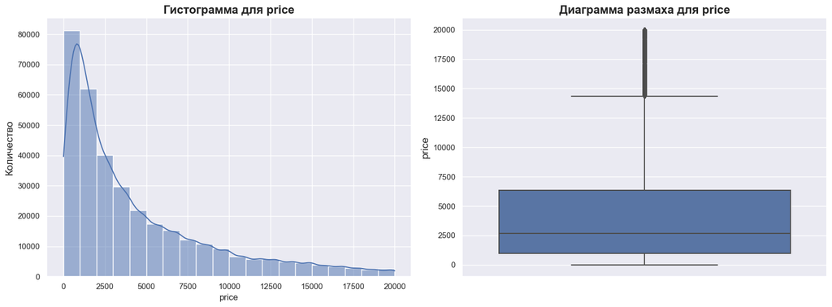

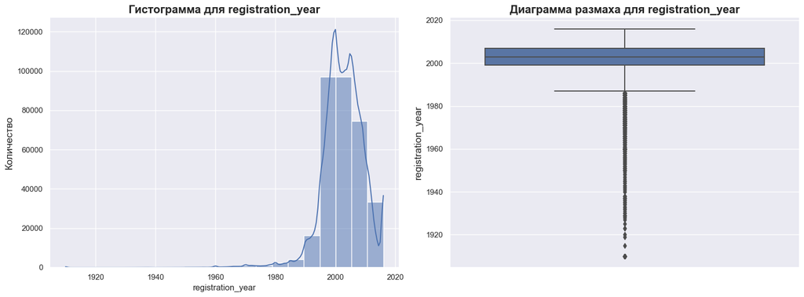

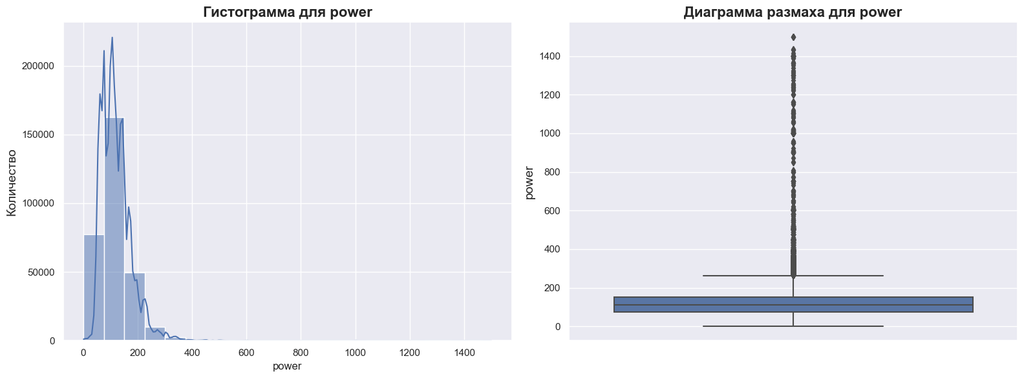

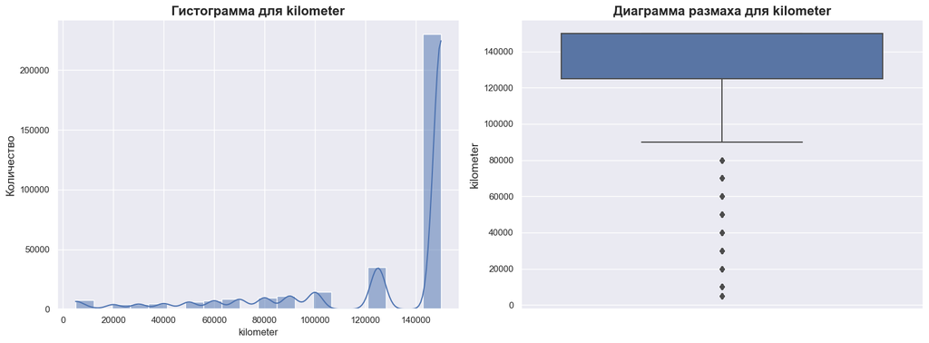

```python
# Вывод графиков для количественных признаков датафрейма autos
for col in num_variables_col:
    show_num_variable(autos, col)
    print('=' * TERM_SIZE)
```

```python
autos.drop(columns=['registration_month', 'last_seen']).describe().round(3)
```

|  | price | registration_year | power | kilometer |
| --- | --- | --- | --- | --- |
| count | 342329.000 | 327994.000 | 303120.000 | 342329.000 |
| mean | 4403.123 | 2002.455 | 120.550 | 128215.576 |
| std | 4514.741 | 7.117 | 58.552 | 37926.407 |
| min | 0.000 | 1910.000 | 1.000 | 5000.000 |
| 25% | 1000.000 | 1999.000 | 75.000 | 125000.000 |
| 50% | 2700.000 | 2003.000 | 110.000 | 150000.000 |
| 75% | 6350.000 | 2007.000 | 150.000 | 150000.000 |
| max | 20000.000 | 2016.000 | 1500.000 | 150000.000 |

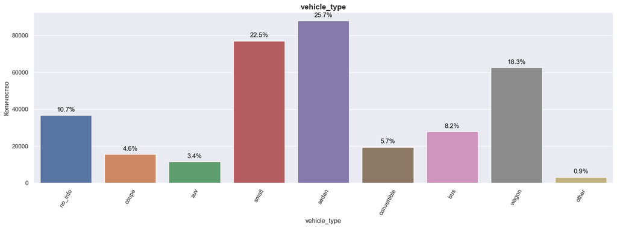

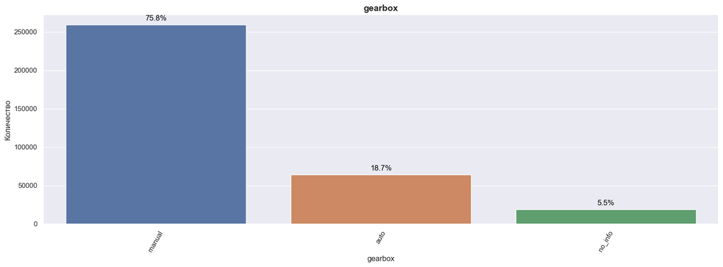

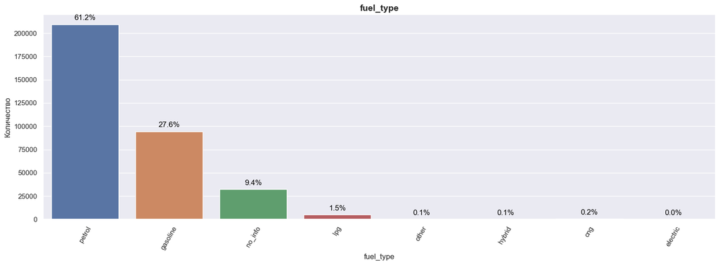

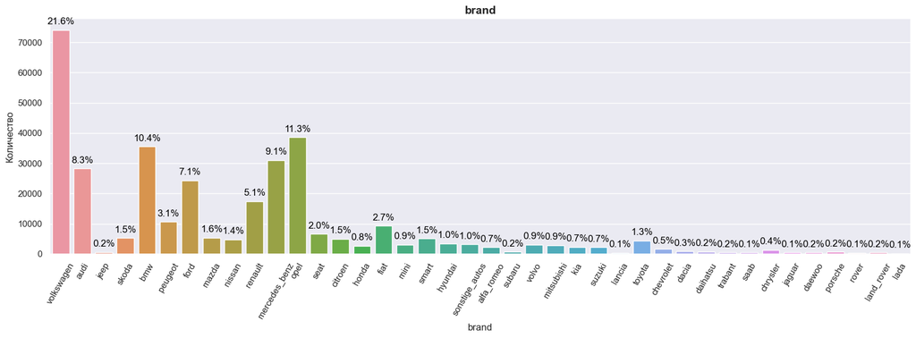

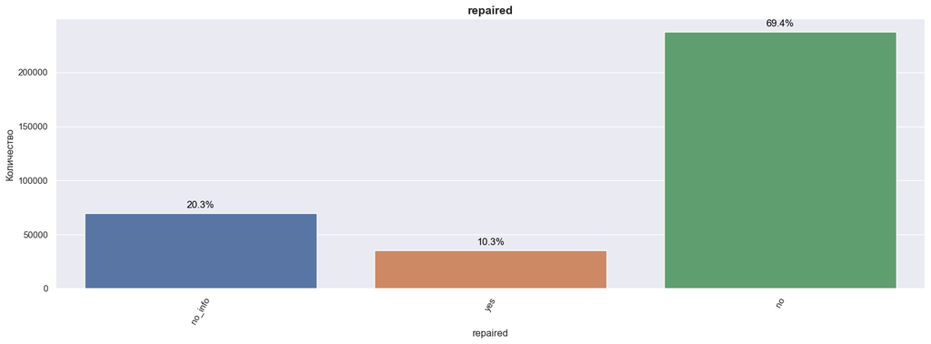

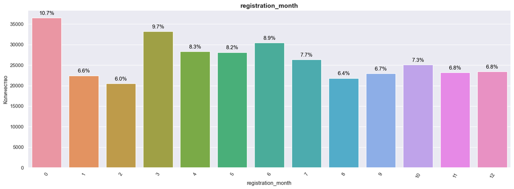

```python
# Лист с названиями столбцов категориальных признаков
cat_columns = autos.select_dtypes(include=['object']).columns.to_list()

cat_columns.remove('model')
cat_columns.append('registration_month')

for col in cat_columns:
    show_cat_variable_by_target(autos, col, col, rot=60)
    print('=' * TERM_SIZE)
```

Был замечен аномальный месяц со значением 0, исправим данный факт присвоив вместо 0 значение no_info

```python
autos['registration_month'] = autos['registration_month'].replace(0, 'no_info')
```

```python
autos['registration_month'].value_counts()
```

```
no_info    36484
3          33186
6          30451
4          28329
5          28120
7          26319
10         25095
12         23424
11         23201
9          22955
1          22444
8          21801
2          20520
Name: registration_month, dtype: int64
```

```python
# Добавим обратно в cat_columns столбец model
cat_columns.append('model')

# Преобразуем сначала столбец registration_month в строковый тип данных, а потом в категориальный, чтобы избежать ошибки при обучении
autos[cat_columns] = autos[cat_columns].astype('str')

# Преобразование категориальных признаков в категориальный тип данных
autos[cat_columns] = autos[cat_columns].astype('category')
```

```python
# Преобразование категориальных признаков в категориальный тип данных
autos[cat_columns] = autos[cat_columns].astype('category')
```

```python
autos[cat_columns].describe()
```

|  | vehicle_type | gearbox | fuel_type | brand | repaired | registration_month | model |
| --- | --- | --- | --- | --- | --- | --- | --- |
| count | 342329 | 342329 | 342329 | 342329 | 342329 | 342329 | 342329 |
| unique | 9 | 3 | 8 | 40 | 3 | 13 | 251 |
| top | sedan | manual | petrol | volkswagen | no | no_info | golf |
| freq | 87980 | 259450 | 209353 | 74107 | 237497 | 36484 | 28087 |

**Вывод**

- Наиболее популярные типы автомобильных кузовов `vehicle_type` - sedan (25.7%), small (22.5%), wagon (18.3%);
- Большинство автомобилей с механической коробкой передач 75.8%;
- Параметр `fuel_type` имеет два самых популярных значения petrol - 61.2% и gasoline - 27.6%. Petrol и gasoline - это бензин;
- Самый популярный бренд автомобилей в датасете volkswagen;
- Чаще всего в объявлениях по прадаже автомобилей указывают, что она не ремонтировалась (не бита) - 69.4%;
- Параметр `registration_month` месяц регистрации автомобиля имеет распределение близкое к равномерному, но все же чаще регистрация автомобилей происходит весной, а реже всего зимой. Самое популярное значение `registration_month` - `no_info`.

## Корреляционный анализ

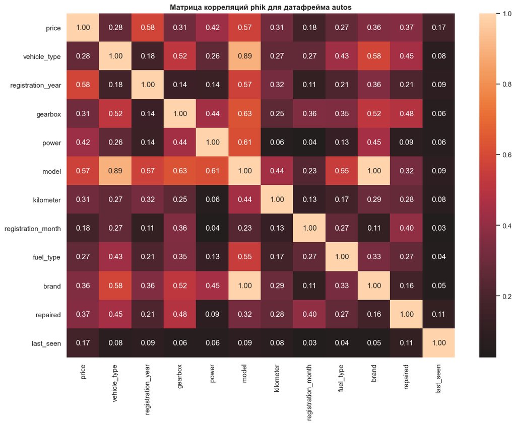

```python
autos_corr = autos.phik_matrix(interval_cols=num_variables_col)
plt.figure(figsize=(14, 10))
sns.heatmap(autos_corr, annot=True, fmt=".2f", center=0)
plt.title('Матрица корреляций phik для датафрейма autos')
plt.show()
```

Замечена мультиколлениарность между входными признаками `model` и `brand`. Примем данный факт во внимание при обучении моделей.

```python
autos_ml = autos
autos_ml.head()
```

|  | price | vehicle_type | registration_year | gearbox | power | model | kilometer | registration_month | fuel_type | brand | repaired | last_seen |
| --- | --- | --- | --- | --- | --- | --- | --- | --- | --- | --- | --- | --- |
| 0 | 480 | no_info | 1993.0 | manual | NaN | golf | 150000 | no_info | petrol | volkswagen | no_info | 2016-04-07 |
| 1 | 18300 | coupe | 2011.0 | manual | 190.0 | no_info | 125000 | 5 | gasoline | audi | yes | 2016-04-07 |
| 2 | 9800 | suv | 2004.0 | auto | 163.0 | grand | 125000 | 8 | gasoline | jeep | no_info | 2016-04-05 |
| 3 | 1500 | small | 2001.0 | manual | 75.0 | golf | 150000 | 6 | petrol | volkswagen | no | 2016-03-17 |
| 4 | 3600 | small | 2008.0 | manual | 69.0 | fabia | 90000 | 7 | gasoline | skoda | no | 2016-04-06 |

**Вывод**

В ходе анализа Phik матрицы корреляций были определены силы связи целевого признака `price` со входными, используя шкалу Чеддока:

- **Заметная связь** целевого признака прослеживается с входными признаками `model` и `registration_year`.
- **Умеренная связь** целевого признака прослеживается с входными признаками `gearbox`, `power`, `kilometer`, `brand` и `repaired`.
- **Слабая связь** целевого признака прослеживается с входными признаками `last_seen`, `fuel_type`, `registration_month` и `vehicle_type`.

## Машинное обучение

### Подготовка данных

```python
# Подготовка данных
X = autos_ml.drop(['price'], axis=1)
y = autos_ml['price']

num_columns = X.select_dtypes(include=['int64', 'float64']).columns.tolist()
cat_columns = X.select_dtypes(include=['category']).columns.tolist()

# Проверка
display(num_columns)
display(cat_columns)

# Разделение на train/test
X_train, X_test, y_train, y_test = train_test_split(
    X, y, test_size=TEST_SIZE, random_state=RANDOM_STATE
)
```

```
['registration_year', 'power', 'kilometer']
```

```
['vehicle_type',
 'gearbox',
 'model',
 'registration_month',
 'fuel_type',
 'brand',
 'repaired']
```

### Модель линейной регрессии

Линейная регрессия не умеет автоматически обрабатывать категориальные признаки и масштабировать количесвенные данные, поэтому проделаем это самостоятельно внутри Pipeline

```python
num_columns = X_train.select_dtypes(include=['int64', 'float64']).columns.tolist()
cat_columns = X_train.select_dtypes(include=['category']).columns.tolist()

# Проверка
display(num_columns)
display(cat_columns)
```

```
['registration_year', 'power', 'kilometer']
```

```
['vehicle_type',
 'gearbox',
 'model',
 'registration_month',
 'fuel_type',
 'brand',
 'repaired']
```

```python
# Обработка числовых и категориальных признаков с импутацией
numeric_transformer = Pipeline(steps=[
    ("imputer", SimpleImputer(strategy="median")),
    ("scaler", StandardScaler())
])

categorical_transformer = Pipeline(steps=[
    ("imputer", SimpleImputer(strategy="constant", fill_value="no_info")),
    ("onehot", OneHotEncoder(drop='first', handle_unknown='ignore', sparse_output=False))
])

preprocessor = ColumnTransformer(
    transformers=[
        ("num", numeric_transformer, num_columns),
        ("cat", categorical_transformer, cat_columns),
    ]
)
```

```python
# Пайплайн
linear_pipe = Pipeline(
    [
        ("preprocessing", preprocessor),
        ("model", LinearRegression()),
    ]
)

# Измерение времени обучения
start_time = time.time()
linear_pipe.fit(X_train, y_train)
training_time_linear = time.time() - start_time

print(f"⏱ Время обучения модели: {training_time_linear:.3f} секунд")
```

```
⏱ Время обучения модели: 6.119 секунд
```

```python
start = time.time()
y_pred_linear = linear_pipe.predict(X_train)
pred_time_linear = time.time() - start

print(f"⏱ Время предсказания модели: {pred_time_linear:.3f} секунд")
```

```
⏱ Время предсказания модели: 0.736 секунд
```

```python
kf = KFold(n_splits=5, shuffle=True, random_state=RANDOM_STATE)
cv_scores = cross_val_score(
    linear_pipe,
    X_train,
    y_train,
    cv=kf,
    scoring='neg_root_mean_squared_error'
)
rmse_linear = -np.mean(cv_scores)
print(f"✅ Среднее RMSE (CV): {rmse_linear:.3f} евро")
```

```
✅ Среднее RMSE (CV): 2807.118 евро
```

### Модель DecisionTreeRegressor

```python
# Обработка числовых и категориальных признаков с импутацией
numeric_transformer_tree = Pipeline(steps=[
    ("imputer", SimpleImputer(strategy="median"))
])

categorical_transformer_tree = Pipeline(steps=[
    ("imputer", SimpleImputer(strategy="constant", fill_value="no_info")),
    ("ord", OrdinalEncoder(handle_unknown="use_encoded_value", unknown_value=np.nan))
])

preprocessor_tree = ColumnTransformer(
    transformers=[
        ("num", numeric_transformer_tree, num_columns),
        ("cat", categorical_transformer_tree, cat_columns),
    ]
)
```

```python
# Пайплайн для модели
tree_pipe = Pipeline(
    [
        ("preprocessing", preprocessor),
        ("model", DecisionTreeRegressor(random_state=RANDOM_STATE)),
    ]
)

# Сетка гиперпараметров для подбора
param_grid = {
    'model__max_depth': [5],
    'model__min_samples_split': [2],
    'model__min_samples_leaf': [2],
}

# GridSearchCV
grid_search_tree = GridSearchCV(
    tree_pipe,
    param_grid=param_grid,
    cv=5,
    scoring='neg_root_mean_squared_error',
    n_jobs=-1
)
```

```python
# Измерение времени обучения для дерева
start_time = time.time()
grid_search_tree.fit(X_train, y_train)

# Вывод результатов
print(f"Лучший результат RMSE: {-grid_search_tree.best_score_:.2f}")
print("Лучшие параметры:", grid_search_tree.best_params_)

training_time_tree = time.time() - start_time

print(f"⏱ Время обучения дерева: {training_time_tree:.3f} секунд")
```

```
Лучший результат RMSE: 2518.32
Лучшие параметры: {'model__max_depth': 5, 'model__min_samples_leaf': 2, 'model__min_samples_split': 2}
⏱ Время обучения дерева: 16.549 секунд
```

```python
# Время предсказания
best_model = grid_search_tree.best_estimator_
start_time = time.time()
y_pred_tree = best_model.predict(X_train)
pred_time_tree = time.time() - start_time

print(f"⏱ Время предсказания модели: {pred_time_tree:.3f} секунд")
```

```
⏱ Время предсказания модели: 0.791 секунд
```

```python
rmse_tree = -grid_search_tree.best_score_
print(f"✅ Среднее RMSE (CV): {rmse_tree:.3f} евро")
```

```
✅ Среднее RMSE (CV): 2518.322 евро
```

### Модель CatBoost

Модель CatBoost умеет работать с пропусками в данных, поэтому заполнять их с помощью Impute не нужно

```python
cb_train = cb.Pool(data=X_train, label=y_train, cat_features=cat_columns)
cb_test = cb.Pool(data=X_test, label=y_test, cat_features=cat_columns)
```

```python
cb_model = cb.CatBoostRegressor(verbose=100, random_seed=RANDOM_STATE, loss_function='RMSE', iterations=500)

start_time = time.time()
cb_model.fit(cb_train)
training_time_cb = time.time() - start_time

print(f"⏱ Время обучения модели CatBoost: {training_time_cb:.3f} секунд")
```

```
Learning rate set to 0.17283
0:	learn: 4030.1698163	total: 255ms	remaining: 2m 7s
100:	learn: 1811.2927823	total: 10.8s	remaining: 42.9s
200:	learn: 1748.4646715	total: 22s	remaining: 32.7s
300:	learn: 1710.3200348	total: 33.4s	remaining: 22.1s
400:	learn: 1685.5535924	total: 44.7s	remaining: 11s
499:	learn: 1665.1621247	total: 56s	remaining: 0us
⏱ Время обучения модели CatBoost: 56.502 секунд
```

```python
start_time = time.time()
cb_pred = cb_model.predict(cb_train)
pred_time_cb = time.time() - start_time
print(f"⏱ Время предсказания модели CatBoost: {pred_time_cb:.3f} секунд")
```

```
⏱ Время предсказания модели CatBoost: 0.193 секунд
```

```python
# Пулы для обучения и теста
cb_train = cb.Pool(data=X_train, label=y_train, cat_features=cat_columns)
cb_test = cb.Pool(data=X_test, label=y_test, cat_features=cat_columns)

# Параметры модели
params = {
    "loss_function": "RMSE",
    "iterations": 500,
    "random_seed": RANDOM_STATE,
    "verbose": False
}

# Кросс-валидация
cv_results = cb.cv(
    params=params,
    pool=cb_train,
    fold_count=5,
    shuffle=True,
    partition_random_seed=RANDOM_STATE,
    verbose=False,
    plot=False
)

# Последнее значение RMSE по кросс-валидации
rmse_cb_cv = cv_results['test-RMSE-mean'].iloc[-1]
print(f"✅ Среднее RMSE по кросс-валидации (CatBoost cv): {rmse_cb_cv:.3f} евро")
```

```
Training on fold [0/5]

bestTest = 1844.238907
bestIteration = 499

Training on fold [1/5]

bestTest = 1836.08455
bestIteration = 499

Training on fold [2/5]

bestTest = 1817.521961
bestIteration = 499

Training on fold [3/5]

bestTest = 1830.824359
bestIteration = 499

Training on fold [4/5]

bestTest = 1853.303122
bestIteration = 499

✅ Среднее RMSE по кросс-валидации (CatBoost cv): 1836.395 евро
```

```python
# Обучение финальной модели на всей обучающей выборке
cb_model = cb.CatBoostRegressor(verbose=100, random_seed=RANDOM_STATE, loss_function='RMSE', iterations=500)

start_time = time.time()
cb_model.fit(cb_train)
training_time_cb = time.time() - start_time
print(f"⏱ Время обучения модели CatBoost: {training_time_cb:.3f} секунд")

start_time = time.time()
cb_pred = cb_model.predict(cb_train)
pred_time_cb = time.time() - start_time
print(f"⏱ Время предсказания модели CatBoost: {pred_time_cb:.3f} секунд")
```

```
Learning rate set to 0.17283
0:	learn: 4030.1698163	total: 134ms	remaining: 1m 7s
100:	learn: 1811.2927823	total: 12.5s	remaining: 49.4s
200:	learn: 1748.4646715	total: 24.5s	remaining: 36.4s
300:	learn: 1710.3200348	total: 37.7s	remaining: 24.9s
400:	learn: 1685.5535924	total: 50.8s	remaining: 12.5s
499:	learn: 1665.1621247	total: 1m 4s	remaining: 0us
⏱ Время обучения модели CatBoost: 65.222 секунд
⏱ Время предсказания модели CatBoost: 0.248 секунд
```

### Модель LightGBM

Модель LightGBM не может напрямую работать с признаками типа datetime, поэтому данные признаки нужно преобразовать

```python
X_train_lgm, X_test_lgm = X_train, X_test

X_train_lgm['last_seen_day'] = X_train_lgm['last_seen'].dt.day
X_train_lgm['last_seen_month'] = X_train_lgm['last_seen'].dt.month
X_train_lgm['last_seen_year'] = X_train_lgm['last_seen'].dt.year
X_train_lgm = X_train_lgm.drop(columns=['last_seen'])

X_test_lgm['last_seen_day'] = X_test_lgm['last_seen'].dt.day
X_test_lgm['last_seen_month'] = X_test_lgm['last_seen'].dt.month
X_test_lgm['last_seen_year'] = X_test_lgm['last_seen'].dt.year
X_test_lgm = X_test_lgm.drop(columns=['last_seen'])
```

```python
lgb_train = lgb.Dataset(X_train_lgm, label=y_train)

params = {
    "objective": "regression",
    "metric": "rmse",
    "verbose": -1,
    "seed": 7
}
```

```python
start_time = time.time()
lgb_model = lgb.train(
    params=params,
    train_set=lgb_train,
)
training_time_lgb = time.time() - start_time

print(f"⏱ Время обучения модели LightGBM: {training_time_lgb:.3f} секунд")
```

```
⏱ Время обучения модели LightGBM: 1.007 секунд
```

```python
# результат вероятности
start_time = time.time()
lgb_pred = lgb_model.predict(X_train_lgm)
pred_time_lgb = time.time() - start_time
print(f"⏱ Время предсказания модели LightGBM: {pred_time_lgb:.3f} секунд")
```

```
⏱ Время предсказания модели LightGBM: 0.357 секунд
```

```python
kf = KFold(n_splits=5, shuffle=True, random_state=RANDOM_STATE)
cv_scores = cross_val_score(
    lgb.LGBMRegressor(**params),
    X_train_lgm,
    y_train,
    cv=kf,
    scoring='neg_root_mean_squared_error'
)
rmse_lgb = -np.mean(cv_scores)
print(f"✅ Среднее RMSE (CV): {rmse_lgb:.3f} евро")
```

```
✅ Среднее RMSE (CV): 1753.421 евро
```

## Анализ результатов

```python
# Создаем таблицу
results_df = pd.DataFrame({
    "Модель": ["LinearRegression", "DecisionTreeRegressor", "CatBoost", "LightGBM"],
    "Время обучения (сек)": [
        round(training_time_linear, 3),
        round(training_time_tree, 3),
        round(training_time_cb, 3),
        round(training_time_lgb, 3)
        ],
    "Время предсказания (сек)": [
        round(pred_time_linear, 3),
        round(pred_time_tree, 3),
        round(pred_time_cb, 3),
        round(pred_time_lgb, 3)
        ],
    "RMSE (евро)": [
        round(rmse_linear, 3),
        round(rmse_tree, 3),
        round(rmse_cb_cv, 3),
        round(rmse_lgb, 3)
        ],
})
```

```python
results_df.index = [''] * len(results_df)
display(results_df)
```

|  | Модель | Время обучения (сек) | Время предсказания (сек) | RMSE (евро) |
| --- | --- | --- | --- | --- |
|  | LinearRegression | 6.119 | 0.736 | 2807.118 |
|  | DecisionTreeRegressor | 16.549 | 0.791 | 2518.322 |
|  | CatBoost | 65.222 | 0.248 | 1836.395 |
|  | LightGBM | 1.007 | 0.357 | 1753.421 |

**Вывод:**

Модель LightGBM быстрее обучается, при схожем времени предсказания, а также имеет лучшую метрику RMSE на кросс-валидации = 1753.4 евро. Поэтому для задачи предсказания цены автомобиля в объявлении, модель LightGBM является **наилучшим вариантом**.

## Тестирование наилучшей модели

Наилучшей моделью на тренировочных данных оказалась LightGBM. Проверим как данная модель поведет себя на тестовой выборке

```python
lgb_pred = lgb_model.predict(X_test_lgm)
rmse_lgb_test = np.sqrt(mean_squared_error(y_test, lgb_pred))
print(f"✅ RMSE на тестовых данных: {rmse_lgb_test:.3f} евро")
```

```
✅ RMSE на тестовых данных: 1759.524 евро
```

Метрика RMSE увеличилась на тестовой выборке с 1753.4 до 1759.5 евро, но она так же удовлетворяет условию (менее 2500).

## Анализ влияния признаков

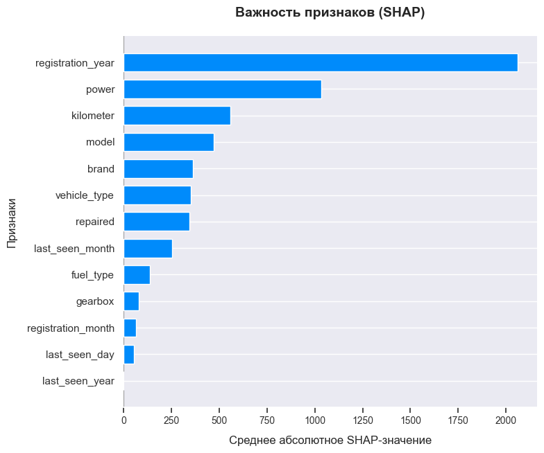

```
График важности признаков успешно построен и сохранен.
Модель: Booster
Количество анализируемых признаков: 13
```

```python
try:
    explainer = shap.TreeExplainer(lgb_model)
    shap_values = explainer.shap_values(X_train_lgm)

    # Создаем фигуру с заданным размером перед построением графика
    plt.figure(figsize=(10, 12))

    # Рисуем bar-график с дополнительными параметрами
    shap.summary_plot(shap_values, X_train_lgm, plot_type="bar", max_display=30, show=False)

    # Настройка графика с более тонкой кастомизацией
    ax = plt.gca()
    ax.set_xlabel("Среднее абсолютное SHAP-значение", fontsize=12, labelpad=10)
    ax.set_ylabel("Признаки", fontsize=12, labelpad=10)
    ax.set_title("Важность признаков (SHAP)", fontsize=14, fontweight='bold', pad=20)

    # Улучшенная настройка шрифтов и отступов
    plt.xticks(fontsize=10)
    plt.yticks(fontsize=11)

    # Добавляем сетку для лучшей читаемости
    ax.grid(axis='x', linestyle='--', alpha=0.6)

    # Оптимизация расположения элементов
    plt.tight_layout()

    # Сохраняем график в файл
    plt.savefig('shap_feature_importance.png', dpi=300, bbox_inches='tight')
    plt.show()

    # Дополнительная информация в консоли
    print("График важности признаков успешно построен и сохранен.")
    print(f"Модель: {type(lgb_model).__name__}")
    print(f"Количество анализируемых признаков: {X_train_lgm.shape[1]}")

except Exception as e:
    print(f"Ошибка при построении SHAP-графика: {str(e)}")
```

**Вывод:**

Наибольшее влияние на предсказание модели LightGBM оказывают входные признаки `registration_year`, `power`, `kilometer`, `model` и `brand`.